# Group members:

## 4)Visualize the results on an interactive web page:

### Trend analysis: visualize number of jobs by locations, by sectors (*similar to part 2.3*):

### - By locations:

```python
city_pattern_job
```

```
Location                        Date
ACT                             2018-10     3579
                                2018-11     1427
                                2018-12     1244
Adelaide                        2018-10     3702
                                2018-11     1434
                                           ...
Yorke Peninsula & Clare Valley  2018-12       17
unknown                         2018-12    29167
                                2019-01    69676
                                2019-02    22003
                                2019-03      402
Name: Title, Length: 199, dtype: int64
```

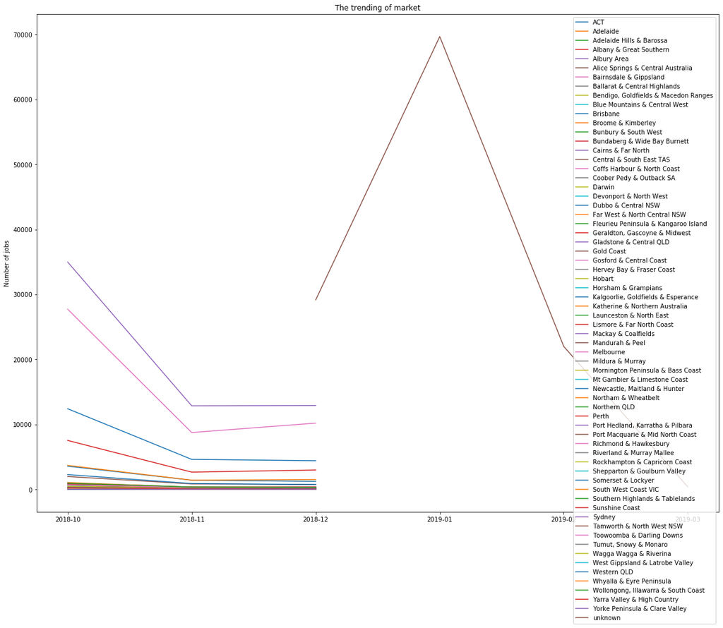

```python
plt.figure(figsize=(20,15))
for location in city_pattern_job.index.get_level_values(0).unique():
    plt.plot(city_pattern_job[location], label=location)
plt.title("The trending of market")
plt.ylabel("Number of jobs")

plt.legend()
plt.show()
```

**Evaluation:**  
Because the the value of data in 2019 has no detailed location, so this evaluation has 2 parts: in 2018 and 2019  
**- 2018**: There are 3 kinds of trend:

1. The number of jobs fall dramatically from 2018-10 to 2018-11 then began to increase slightly in 2018-12.
2. The number of jobs fall from 2018-10 to 2018-11 then kept falling in 2018-12 but more slightly.
3. The number of jobs fall from 2018-10 to 2018-11 then kept stable in 2018-12

**- 2019**: The number of jobs increased sharply from 2018-12 to 2019-01 then decreased until 2019-03

### - By sectors:

```python
MarketTrend
```

```
Classification                   Date
Accounting                       2018-10     5488
                                 2018-11     1824
                                 2018-12     2056
Administration & Office Support  2018-10     5608
                                 2018-11     2519
                                            ...
Trades & Services                2018-12     3464
unknown                          2018-12    29167
                                 2019-01    69676
                                 2019-02    22003
                                 2019-03      402
Name: Classification, Length: 94, dtype: int64
```

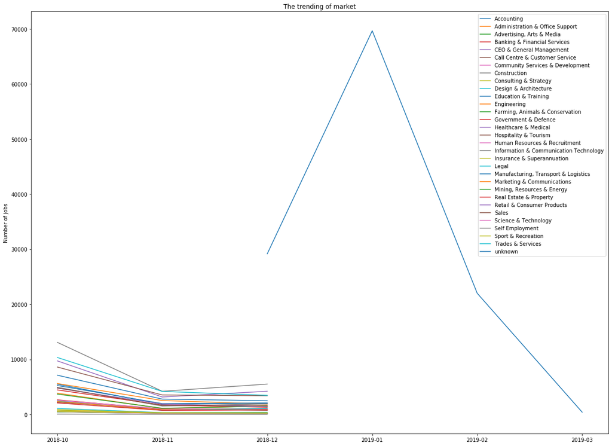

```python
plt.figure(figsize=(20,15))
for sector in MarketTrend.index.get_level_values(0).unique():
    plt.plot(MarketTrend[sector], label=sector)
plt.title("The trending of market")
plt.ylabel("Number of jobs")

plt.legend()
plt.show()
```

Base on the chart above:  
**2018**: The market has 3 trends: the most of jobs plummeted from 10-2018 to 11-2018 and increase to 12-2018; some jobs descrease from 10-2018 to 12-2018 and the rest has no change overtime. Information and Communication Technology is the hotest job in the market because it is the highest frequency job.  
**2019**: The number of jobs increased sharply from 2018-12 to 2019-01 then decreased until 2019-03

### Compare between locations or sectors about the number of jobs and the salary:

### - Between locations

Number of jobs comparision:

```python
df_job_city = df.groupby('Location')['Title'].count().sort_values(ascending=True)
df_job_city
```

```
Location
Central & South East TAS                   57
Fleurieu Peninsula & Kangaroo Island       64
Somerset & Lockyer                         65
Tumut, Snowy & Monaro                      86
Yorke Peninsula & Clare Valley             96
                                        ...
Adelaide                                 6653
Perth                                   13198
Brisbane                                21466
Melbourne                               46690
Sydney                                  60765
Name: Title, Length: 65, dtype: int64
```

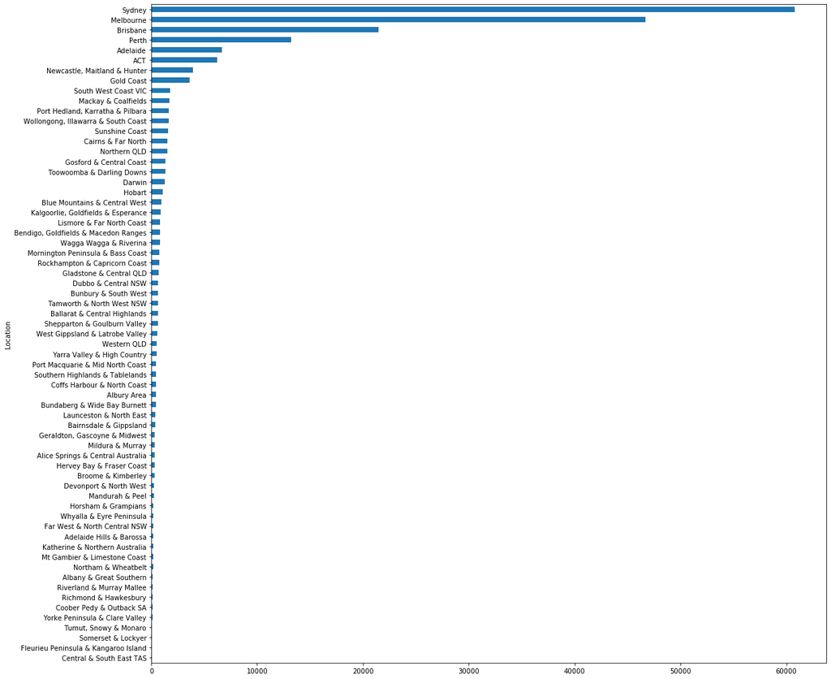

```python
df_job_city.plot(kind='barh', stacked=True, figsize=(18,18))
```

Evaluation: **Sydney** and **Melbournce** are top 2 city which have the most number of jobs, and these figures are much higher than the others.

Salary comparision:

```python
high_sortedDF
```

| Location | LowestSalary | HighestSalary | SalaryRange |
| --- | --- | --- | --- |
| Fleurieu Peninsula & Kangaroo Island | 42.968750 | 58.125000 | 15.156250 |
| Riverland & Murray Mallee | 48.926174 | 64.697987 | 15.771812 |
| Central & South East TAS | 51.754386 | 68.245614 | 16.491228 |
| Yarra Valley & High Country | 44.168337 | 68.945892 | 24.777555 |
| Adelaide Hills & Barossa | 41.191710 | 68.948187 | 27.756477 |
| ... | ... | ... | ... |
| Tumut, Snowy & Monaro | 67.558140 | 133.081395 | 65.523256 |
| Western QLD | 69.357977 | 134.128405 | 64.770428 |
| Sydney | 71.882004 | 134.751041 | 62.869036 |
| Port Macquarie & Mid North Coast | 71.812367 | 149.605544 | 77.793177 |
| ACT | 86.174400 | 198.718240 | 112.543840 |

65 rows × 3 columns

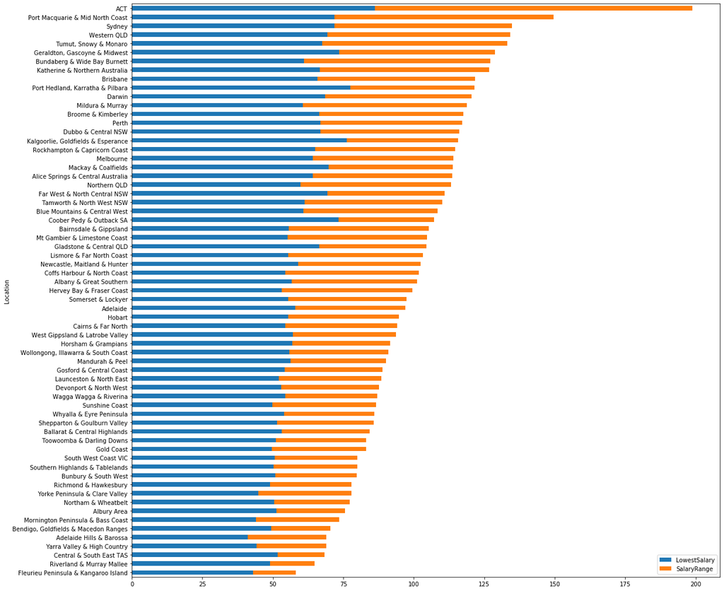

```python
high_sortedDF[['LowestSalary', 'SalaryRange']].plot(kind='barh', stacked=True, figsize=(18,18))
```

Evaluation: **ACT** has most-paid jobs

### - Between sectors:

Number of jobs comparision:

```python
CompareSector = df.groupby('Classification')['Title'].count().sort_values(ascending=True)
CompareSector
```

```
Classification
Self Employment                              93
Advertising, Arts & Media                   833
CEO & General Management                    844
Farming, Animals & Conservation             882
Science & Technology                        905
Sport & Recreation                          984
Consulting & Strategy                      1206
Insurance & Superannuation                 1474
Design & Architecture                      1811
Real Estate & Property                     3614
Marketing & Communications                 3968
Call Centre & Customer Service             3971
Human Resources & Recruitment              4144
Legal                                      4237
Community Services & Development           4485
Banking & Financial Services               4633
Mining, Resources & Energy                 6288
Engineering                                6458
Government & Defence                       7443
Retail & Consumer Products                 8041
Sales                                      8119
Construction                               8372
Education & Training                       9280
Accounting                                 9368
Administration & Office Support           10020
Manufacturing, Transport & Logistics      12376
Hospitality & Tourism                     15523
Healthcare & Medical                      17085
Trades & Services                         17976
Information & Communication Technology    22796
Name: Title, dtype: int64
```

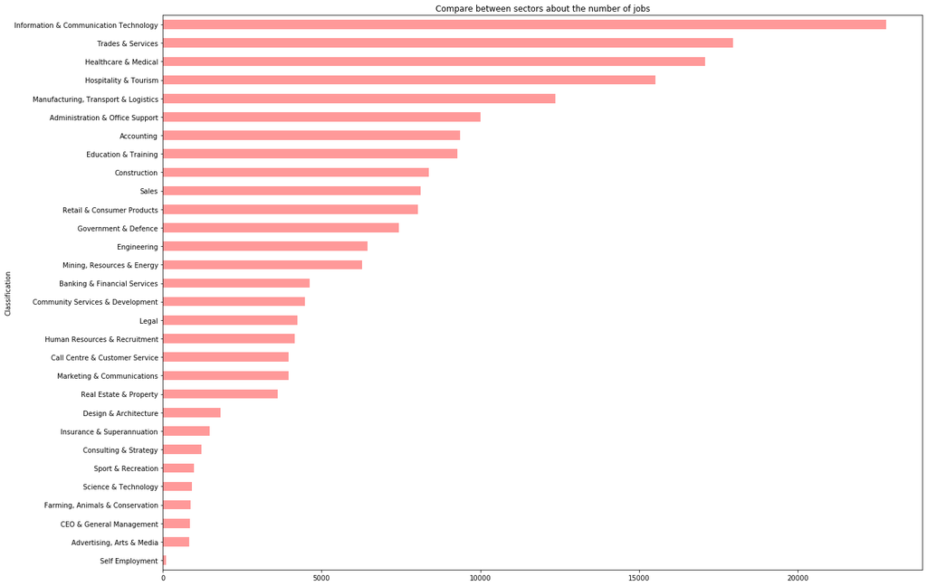

```python
plt.figure(figsize=(20,15))
plt.title("Compare between sectors about the number of jobs")
plt.ylabel("Classification")

CompareSector.plot(kind = 'barh', alpha=0.4, color='r')
```

Evaluation: **Information & Communication Technology**, **Trades & Service** and **Heathcare & Medical** are top 3 sectors that have the most number of jobs.

Salary comparision:

```python
SalSector
```

| Sector | LowestSalary | HighestSalary | Range |
| --- | --- | --- | --- |
|  | 65.399512 | 105.199418 | 39.799906 |
| Accounting | 67.137062 | 108.139838 | 41.002775 |
| Administration & Office Support | 40.057884 | 57.147705 | 17.089820 |
| Advertising, Arts & Media | 56.062425 | 84.644658 | 28.582233 |
| Banking & Financial Services | 78.508526 | 143.533779 | 65.025254 |
| CEO & General Management | 126.741706 | 384.127962 | 257.386256 |
| Call Centre & Customer Service | 39.790985 | 57.398136 | 17.607152 |
| Community Services & Development | 47.977703 | 68.732219 | 20.754515 |
| Construction | 89.939083 | 163.196011 | 73.256928 |
| Consulting & Strategy | 101.948590 | 213.184909 | 111.236318 |
| Design & Architecture | 67.355052 | 111.046383 | 43.691331 |
| Education & Training | 59.173491 | 86.236530 | 27.063039 |
| Engineering | 90.346857 | 152.014710 | 61.667854 |
| Farming, Animals & Conservation | 46.972789 | 68.621315 | 21.648526 |
| Government & Defence | 75.943840 | 131.460701 | 55.516861 |
| Healthcare & Medical | 72.934738 | 162.015920 | 89.081182 |
| Hospitality & Tourism | 33.081879 | 47.406558 | 14.324680 |
| Human Resources & Recruitment | 69.734556 | 109.499276 | 39.764720 |
| Information & Communication Technology | 108.765573 | 256.279084 | 147.513511 |
| Insurance & Superannuation | 67.876526 | 105.000000 | 37.123474 |
| Legal | 87.481709 | 156.894501 | 69.412792 |
| Manufacturing, Transport & Logistics | 46.964286 | 70.607708 | 23.643423 |
| Marketing & Communications | 67.825101 | 101.468750 | 33.643649 |
| Mining, Resources & Energy | 92.293257 | 164.978849 | 72.685592 |
| Real Estate & Property | 57.927504 | 100.794687 | 42.867183 |
| Retail & Consumer Products | 36.608631 | 53.476806 | 16.868176 |
| Sales | 63.446237 | 101.293263 | 37.847025 |
| Science & Technology | 74.320442 | 127.893923 | 53.573481 |
| Self Employment | 70.967742 | 111.806452 | 40.838710 |
| Sport & Recreation | 45.203252 | 73.359756 | 28.156504 |
| Trades & Services | 44.829217 | 61.948821 | 17.119604 |

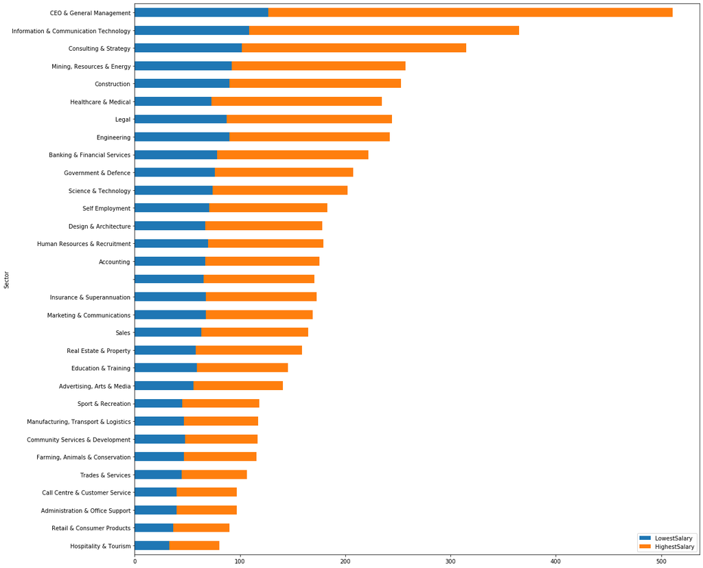

```python
SalSector[['LowestSalary','HighestSalary']].sort_values(by=['HighestSalary']).plot(kind='barh', stacked=True, figsize=(18,18))
```

Evaluation: **CEO & Geneneral Management**, **ICT** and **Consulting & Strategy** are most-paid sectors.